# Part I - (Fordbike Analysis)

## Introduction

> This data contains information about 183,412 bike trips made in a bike sharing system covering the greater San Francisco Bay area.

## Preliminary Wrangling

```python
# import all packages and set plots to be embedded inline
import numpy as np
import pandas as pd
import matplotlib.pyplot as plt
import seaborn as sb
import datetime as dt

%matplotlib inline
```

> Load in your dataset and describe its properties through the questions below. Try and motivate your exploration goals through this section.

```python
# Load in the dataset into a pandas dataframe, print statistics
fordbike= pd.read_csv('201902-fordgobike-tripdata.csv')
```

```python
fordbike.head()
```

|  | duration_sec | start_time | end_time | start_station_id | start_station_name | start_station_latitude | start_station_longitude | end_station_id | end_station_name | end_station_latitude | end_station_longitude | bike_id | user_type | member_birth_year | member_gender | bike_share_for_all_trip |
| --- | --- | --- | --- | --- | --- | --- | --- | --- | --- | --- | --- | --- | --- | --- | --- | --- |
| 0 | 52185 | 2019-02-28 17:32:10.1450 | 2019-03-01 08:01:55.9750 | 21.0 | Montgomery St BART Station (Market St at 2nd St) | 37.789625 | -122.400811 | 13.0 | Commercial St at Montgomery St | 37.794231 | -122.402923 | 4902 | Customer | 1984.0 | Male | No |
| 1 | 42521 | 2019-02-28 18:53:21.7890 | 2019-03-01 06:42:03.0560 | 23.0 | The Embarcadero at Steuart St | 37.791464 | -122.391034 | 81.0 | Berry St at 4th St | 37.775880 | -122.393170 | 2535 | Customer | NaN | NaN | No |
| 2 | 61854 | 2019-02-28 12:13:13.2180 | 2019-03-01 05:24:08.1460 | 86.0 | Market St at Dolores St | 37.769305 | -122.426826 | 3.0 | Powell St BART Station (Market St at 4th St) | 37.786375 | -122.404904 | 5905 | Customer | 1972.0 | Male | No |
| 3 | 36490 | 2019-02-28 17:54:26.0100 | 2019-03-01 04:02:36.8420 | 375.0 | Grove St at Masonic Ave | 37.774836 | -122.446546 | 70.0 | Central Ave at Fell St | 37.773311 | -122.444293 | 6638 | Subscriber | 1989.0 | Other | No |
| 4 | 1585 | 2019-02-28 23:54:18.5490 | 2019-03-01 00:20:44.0740 | 7.0 | Frank H Ogawa Plaza | 37.804562 | -122.271738 | 222.0 | 10th Ave at E 15th St | 37.792714 | -122.248780 | 4898 | Subscriber | 1974.0 | Male | Yes |

```python
fordbike.tail()
```

|  | duration_sec | start_time | end_time | start_station_id | start_station_name | start_station_latitude | start_station_longitude | end_station_id | end_station_name | end_station_latitude | end_station_longitude | bike_id | user_type | member_birth_year | member_gender | bike_share_for_all_trip |
| --- | --- | --- | --- | --- | --- | --- | --- | --- | --- | --- | --- | --- | --- | --- | --- | --- |
| 183407 | 480 | 2019-02-01 00:04:49.7240 | 2019-02-01 00:12:50.0340 | 27.0 | Beale St at Harrison St | 37.788059 | -122.391865 | 324.0 | Union Square (Powell St at Post St) | 37.788300 | -122.408531 | 4832 | Subscriber | 1996.0 | Male | No |
| 183408 | 313 | 2019-02-01 00:05:34.7440 | 2019-02-01 00:10:48.5020 | 21.0 | Montgomery St BART Station (Market St at 2nd St) | 37.789625 | -122.400811 | 66.0 | 3rd St at Townsend St | 37.778742 | -122.392741 | 4960 | Subscriber | 1984.0 | Male | No |
| 183409 | 141 | 2019-02-01 00:06:05.5490 | 2019-02-01 00:08:27.2200 | 278.0 | The Alameda at Bush St | 37.331932 | -121.904888 | 277.0 | Morrison Ave at Julian St | 37.333658 | -121.908586 | 3824 | Subscriber | 1990.0 | Male | Yes |
| 183410 | 139 | 2019-02-01 00:05:34.3600 | 2019-02-01 00:07:54.2870 | 220.0 | San Pablo Ave at MLK Jr Way | 37.811351 | -122.273422 | 216.0 | San Pablo Ave at 27th St | 37.817827 | -122.275698 | 5095 | Subscriber | 1988.0 | Male | No |
| 183411 | 271 | 2019-02-01 00:00:20.6360 | 2019-02-01 00:04:52.0580 | 24.0 | Spear St at Folsom St | 37.789677 | -122.390428 | 37.0 | 2nd St at Folsom St | 37.785000 | -122.395936 | 1057 | Subscriber | 1989.0 | Male | No |

```python
# high-level overview of data shape and composition
print(fordbike.shape)
print(fordbike.dtypes)
```

```
(183412, 16)
duration_sec                 int64
start_time                  object
end_time                    object
start_station_id           float64
start_station_name          object
start_station_latitude     float64
start_station_longitude    float64
end_station_id             float64
end_station_name            object
end_station_latitude       float64
end_station_longitude      float64
bike_id                      int64
user_type                   object
member_birth_year          float64
member_gender               object
bike_share_for_all_trip     object
dtype: object
```

```python
# statactical description of the dataset
fordbike.describe()
```

|  | duration_sec | start_station_id | start_station_latitude | start_station_longitude | end_station_id | end_station_latitude | end_station_longitude | bike_id | member_birth_year |
| --- | --- | --- | --- | --- | --- | --- | --- | --- | --- |
| count | 183412.000000 | 183215.000000 | 183412.000000 | 183412.000000 | 183215.000000 | 183412.000000 | 183412.000000 | 183412.000000 | 175147.000000 |
| mean | 726.078435 | 138.590427 | 37.771223 | -122.352664 | 136.249123 | 37.771427 | -122.352250 | 4472.906375 | 1984.806437 |
| std | 1794.389780 | 111.778864 | 0.099581 | 0.117097 | 111.515131 | 0.099490 | 0.116673 | 1664.383394 | 10.116689 |
| min | 61.000000 | 3.000000 | 37.317298 | -122.453704 | 3.000000 | 37.317298 | -122.453704 | 11.000000 | 1878.000000 |
| 25% | 325.000000 | 47.000000 | 37.770083 | -122.412408 | 44.000000 | 37.770407 | -122.411726 | 3777.000000 | 1980.000000 |
| 50% | 514.000000 | 104.000000 | 37.780760 | -122.398285 | 100.000000 | 37.781010 | -122.398279 | 4958.000000 | 1987.000000 |
| 75% | 796.000000 | 239.000000 | 37.797280 | -122.286533 | 235.000000 | 37.797320 | -122.288045 | 5502.000000 | 1992.000000 |
| max | 85444.000000 | 398.000000 | 37.880222 | -121.874119 | 398.000000 | 37.880222 | -121.874119 | 6645.000000 | 2001.000000 |

```python
# overview of the dataset
fordbike.info()
```

```
<class 'pandas.core.frame.DataFrame'>
RangeIndex: 183412 entries, 0 to 183411
Data columns (total 16 columns):
 #   Column                   Non-Null Count   Dtype
---  ------                   --------------   -----
 0   duration_sec             183412 non-null  int64
 1   start_time               183412 non-null  object
 2   end_time                 183412 non-null  object
 3   start_station_id         183215 non-null  float64
 4   start_station_name       183215 non-null  object
 5   start_station_latitude   183412 non-null  float64
 6   start_station_longitude  183412 non-null  float64
 7   end_station_id           183215 non-null  float64
 8   end_station_name         183215 non-null  object
 9   end_station_latitude     183412 non-null  float64
 10  end_station_longitude    183412 non-null  float64
 11  bike_id                  183412 non-null  int64
 12  user_type                183412 non-null  object
 13  member_birth_year        175147 non-null  float64
 14  member_gender            175147 non-null  object
 15  bike_share_for_all_trip  183412 non-null  object
dtypes: float64(7), int64(2), object(7)
memory usage: 22.4+ MB
```

```python
# Check if Nan Values are present
fordbike.isnull().sum()
```

```
duration_sec                  0
start_time                    0
end_time                      0
start_station_id            197
start_station_name          197
start_station_latitude        0
start_station_longitude       0
end_station_id              197
end_station_name            197
end_station_latitude          0
end_station_longitude         0
bike_id                       0
user_type                     0
member_birth_year          8265
member_gender              8265
bike_share_for_all_trip       0
dtype: int64
```

## Data Wrangling

- Drop data with missing values
- Convert the start and end time column to DateTime
- Convert the bike id to string
- Calculate member age from the member birth year
- Extract From the start and end column the day, month and year

### Cleaning dataset

```python
# Make a copy of every data
fb_clean = fordbike.copy()
```

### Define

Drop data with missing values

### Code

```python
fb_clean.dropna(inplace=True)
```

### Test

```python
fb_clean.info()
```

```
<class 'pandas.core.frame.DataFrame'>
Int64Index: 174952 entries, 0 to 183411
Data columns (total 16 columns):
 #   Column                   Non-Null Count   Dtype
---  ------                   --------------   -----
 0   duration_sec             174952 non-null  int64
 1   start_time               174952 non-null  object
 2   end_time                 174952 non-null  object
 3   start_station_id         174952 non-null  float64
 4   start_station_name       174952 non-null  object
 5   start_station_latitude   174952 non-null  float64
 6   start_station_longitude  174952 non-null  float64
 7   end_station_id           174952 non-null  float64
 8   end_station_name         174952 non-null  object
 9   end_station_latitude     174952 non-null  float64
 10  end_station_longitude    174952 non-null  float64
 11  bike_id                  174952 non-null  int64
 12  user_type                174952 non-null  object
 13  member_birth_year        174952 non-null  float64
 14  member_gender            174952 non-null  object
 15  bike_share_for_all_trip  174952 non-null  object
dtypes: float64(7), int64(2), object(7)
memory usage: 22.7+ MB
```

### Define

Convert the start and end time column to Date Time

### Code

```python
fb_clean.start_time = pd.to_datetime(fb_clean.start_time)
fb_clean.end_time = pd.to_datetime(fb_clean.end_time)
```

### Test

```python
fb_clean.start_time.dtype
```

```
dtype('<M8[ns]')
```

```python
fb_clean.end_time.dtype
```

```
dtype('<M8[ns]')
```

### Define

Convert the bike id to string

### Code

```python
fb_clean.bike_id = fb_clean.bike_id.astype(str)
```

### Test

```python
fb_clean.info()
```

```
<class 'pandas.core.frame.DataFrame'>
Int64Index: 174952 entries, 0 to 183411
Data columns (total 16 columns):
 #   Column                   Non-Null Count   Dtype
---  ------                   --------------   -----
 0   duration_sec             174952 non-null  int64
 1   start_time               174952 non-null  datetime64[ns]
 2   end_time                 174952 non-null  datetime64[ns]
 3   start_station_id         174952 non-null  float64
 4   start_station_name       174952 non-null  object
 5   start_station_latitude   174952 non-null  float64
 6   start_station_longitude  174952 non-null  float64
 7   end_station_id           174952 non-null  float64
 8   end_station_name         174952 non-null  object
 9   end_station_latitude     174952 non-null  float64
 10  end_station_longitude    174952 non-null  float64
 11  bike_id                  174952 non-null  object
 12  user_type                174952 non-null  object
 13  member_birth_year        174952 non-null  float64
 14  member_gender            174952 non-null  object
 15  bike_share_for_all_trip  174952 non-null  object
dtypes: datetime64[ns](2), float64(7), int64(1), object(6)
memory usage: 22.7+ MB
```

### Define

Calculate the age from the birth year

### Code

```python
fb_clean["member_birth_age"] = 2019 - fb_clean["member_birth_year"]
```

### Test

```python
fb_clean
```

|  | duration_sec | start_time | end_time | start_station_id | start_station_name | start_station_latitude | start_station_longitude | end_station_id | end_station_name | end_station_latitude | end_station_longitude | bike_id | user_type | member_birth_year | member_gender | bike_share_for_all_trip | member_birth_age |
| --- | --- | --- | --- | --- | --- | --- | --- | --- | --- | --- | --- | --- | --- | --- | --- | --- | --- |
| 0 | 52185 | 2019-02-28 17:32:10.145 | 2019-03-01 08:01:55.975 | 21.0 | Montgomery St BART Station (Market St at 2nd St) | 37.789625 | -122.400811 | 13.0 | Commercial St at Montgomery St | 37.794231 | -122.402923 | 4902 | Customer | 1984.0 | Male | No | 35.0 |
| 2 | 61854 | 2019-02-28 12:13:13.218 | 2019-03-01 05:24:08.146 | 86.0 | Market St at Dolores St | 37.769305 | -122.426826 | 3.0 | Powell St BART Station (Market St at 4th St) | 37.786375 | -122.404904 | 5905 | Customer | 1972.0 | Male | No | 47.0 |
| 3 | 36490 | 2019-02-28 17:54:26.010 | 2019-03-01 04:02:36.842 | 375.0 | Grove St at Masonic Ave | 37.774836 | -122.446546 | 70.0 | Central Ave at Fell St | 37.773311 | -122.444293 | 6638 | Subscriber | 1989.0 | Other | No | 30.0 |
| 4 | 1585 | 2019-02-28 23:54:18.549 | 2019-03-01 00:20:44.074 | 7.0 | Frank H Ogawa Plaza | 37.804562 | -122.271738 | 222.0 | 10th Ave at E 15th St | 37.792714 | -122.248780 | 4898 | Subscriber | 1974.0 | Male | Yes | 45.0 |
| 5 | 1793 | 2019-02-28 23:49:58.632 | 2019-03-01 00:19:51.760 | 93.0 | 4th St at Mission Bay Blvd S | 37.770407 | -122.391198 | 323.0 | Broadway at Kearny | 37.798014 | -122.405950 | 5200 | Subscriber | 1959.0 | Male | No | 60.0 |
| ... | ... | ... | ... | ... | ... | ... | ... | ... | ... | ... | ... | ... | ... | ... | ... | ... | ... |
| 183407 | 480 | 2019-02-01 00:04:49.724 | 2019-02-01 00:12:50.034 | 27.0 | Beale St at Harrison St | 37.788059 | -122.391865 | 324.0 | Union Square (Powell St at Post St) | 37.788300 | -122.408531 | 4832 | Subscriber | 1996.0 | Male | No | 23.0 |
| 183408 | 313 | 2019-02-01 00:05:34.744 | 2019-02-01 00:10:48.502 | 21.0 | Montgomery St BART Station (Market St at 2nd St) | 37.789625 | -122.400811 | 66.0 | 3rd St at Townsend St | 37.778742 | -122.392741 | 4960 | Subscriber | 1984.0 | Male | No | 35.0 |
| 183409 | 141 | 2019-02-01 00:06:05.549 | 2019-02-01 00:08:27.220 | 278.0 | The Alameda at Bush St | 37.331932 | -121.904888 | 277.0 | Morrison Ave at Julian St | 37.333658 | -121.908586 | 3824 | Subscriber | 1990.0 | Male | Yes | 29.0 |
| 183410 | 139 | 2019-02-01 00:05:34.360 | 2019-02-01 00:07:54.287 | 220.0 | San Pablo Ave at MLK Jr Way | 37.811351 | -122.273422 | 216.0 | San Pablo Ave at 27th St | 37.817827 | -122.275698 | 5095 | Subscriber | 1988.0 | Male | No | 31.0 |
| 183411 | 271 | 2019-02-01 00:00:20.636 | 2019-02-01 00:04:52.058 | 24.0 | Spear St at Folsom St | 37.789677 | -122.390428 | 37.0 | 2nd St at Folsom St | 37.785000 | -122.395936 | 1057 | Subscriber | 1989.0 | Male | No | 30.0 |

174952 rows × 17 columns

### Define

Extract From the start and end column the day, month and year

### Code

```python
fb_clean["start_hour"] = fb_clean["start_time"].dt.hour
fb_clean["start_day"] = fb_clean["start_time"].dt.day_name()
fb_clean["start_month"] = fb_clean["start_time"].dt.month_name()
fb_clean["start_year"] = fb_clean["start_time"].dt.year
fb_clean["start_year"] = fb_clean["start_time"].astype(str)

fb_clean["end_hour"] = fb_clean["end_time"].dt.hour
fb_clean["end_day"] = fb_clean["end_time"].dt.day_name()
fb_clean["end_month"] = fb_clean["end_time"].dt.month_name()
fb_clean["end_year"] = fb_clean["end_time"].dt.year
fb_clean["end_year"] = fb_clean["end_time"].astype(str)
```

### Test

```python
fb_clean
```

|  | duration_sec | start_time | end_time | start_station_id | start_station_name | start_station_latitude | start_station_longitude | end_station_id | end_station_name | end_station_latitude | ... | bike_share_for_all_trip | member_birth_age | start_hour | start_day | start_month | start_year | end_hour | end_day | end_month | end_year |
| --- | --- | --- | --- | --- | --- | --- | --- | --- | --- | --- | --- | --- | --- | --- | --- | --- | --- | --- | --- | --- | --- |
| 0 | 52185 | 2019-02-28 17:32:10.145 | 2019-03-01 08:01:55.975 | 21.0 | Montgomery St BART Station (Market St at 2nd St) | 37.789625 | -122.400811 | 13.0 | Commercial St at Montgomery St | 37.794231 | ... | No | 35.0 | 17 | Thursday | February | 2019-02-28 17:32:10.145 | 8 | Friday | March | 2019-03-01 08:01:55.975 |
| 2 | 61854 | 2019-02-28 12:13:13.218 | 2019-03-01 05:24:08.146 | 86.0 | Market St at Dolores St | 37.769305 | -122.426826 | 3.0 | Powell St BART Station (Market St at 4th St) | 37.786375 | ... | No | 47.0 | 12 | Thursday | February | 2019-02-28 12:13:13.218 | 5 | Friday | March | 2019-03-01 05:24:08.146 |
| 3 | 36490 | 2019-02-28 17:54:26.010 | 2019-03-01 04:02:36.842 | 375.0 | Grove St at Masonic Ave | 37.774836 | -122.446546 | 70.0 | Central Ave at Fell St | 37.773311 | ... | No | 30.0 | 17 | Thursday | February | 2019-02-28 17:54:26.010 | 4 | Friday | March | 2019-03-01 04:02:36.842 |
| 4 | 1585 | 2019-02-28 23:54:18.549 | 2019-03-01 00:20:44.074 | 7.0 | Frank H Ogawa Plaza | 37.804562 | -122.271738 | 222.0 | 10th Ave at E 15th St | 37.792714 | ... | Yes | 45.0 | 23 | Thursday | February | 2019-02-28 23:54:18.549 | 0 | Friday | March | 2019-03-01 00:20:44.074 |
| 5 | 1793 | 2019-02-28 23:49:58.632 | 2019-03-01 00:19:51.760 | 93.0 | 4th St at Mission Bay Blvd S | 37.770407 | -122.391198 | 323.0 | Broadway at Kearny | 37.798014 | ... | No | 60.0 | 23 | Thursday | February | 2019-02-28 23:49:58.632 | 0 | Friday | March | 2019-03-01 00:19:51.760 |
| ... | ... | ... | ... | ... | ... | ... | ... | ... | ... | ... | ... | ... | ... | ... | ... | ... | ... | ... | ... | ... | ... |
| 183407 | 480 | 2019-02-01 00:04:49.724 | 2019-02-01 00:12:50.034 | 27.0 | Beale St at Harrison St | 37.788059 | -122.391865 | 324.0 | Union Square (Powell St at Post St) | 37.788300 | ... | No | 23.0 | 0 | Friday | February | 2019-02-01 00:04:49.724 | 0 | Friday | February | 2019-02-01 00:12:50.034 |
| 183408 | 313 | 2019-02-01 00:05:34.744 | 2019-02-01 00:10:48.502 | 21.0 | Montgomery St BART Station (Market St at 2nd St) | 37.789625 | -122.400811 | 66.0 | 3rd St at Townsend St | 37.778742 | ... | No | 35.0 | 0 | Friday | February | 2019-02-01 00:05:34.744 | 0 | Friday | February | 2019-02-01 00:10:48.502 |
| 183409 | 141 | 2019-02-01 00:06:05.549 | 2019-02-01 00:08:27.220 | 278.0 | The Alameda at Bush St | 37.331932 | -121.904888 | 277.0 | Morrison Ave at Julian St | 37.333658 | ... | Yes | 29.0 | 0 | Friday | February | 2019-02-01 00:06:05.549 | 0 | Friday | February | 2019-02-01 00:08:27.220 |
| 183410 | 139 | 2019-02-01 00:05:34.360 | 2019-02-01 00:07:54.287 | 220.0 | San Pablo Ave at MLK Jr Way | 37.811351 | -122.273422 | 216.0 | San Pablo Ave at 27th St | 37.817827 | ... | No | 31.0 | 0 | Friday | February | 2019-02-01 00:05:34.360 | 0 | Friday | February | 2019-02-01 00:07:54.287 |
| 183411 | 271 | 2019-02-01 00:00:20.636 | 2019-02-01 00:04:52.058 | 24.0 | Spear St at Folsom St | 37.789677 | -122.390428 | 37.0 | 2nd St at Folsom St | 37.785000 | ... | No | 30.0 | 0 | Friday | February | 2019-02-01 00:00:20.636 | 0 | Friday | February | 2019-02-01 00:04:52.058 |

174952 rows × 25 columns

### Store

```python
# Save clean dataframe to csv
fb_clean.to_csv('fordbike_archive_master.csv', index=False)
```

### What is the structure of your dataset?

> There are 183,412 rows and 16 columns. There are some missing datas such as "start_station_id", "start_station_name", "end_station_id", "end_station_name", "member_birth_year", "member_gender_year".

### What is/are the main feature(s) of interest in your dataset?

> From my opionion, the main features of interest are user_type, member_gender, members_birth_age, duration_sec, start_time and end_time.

### What features in the dataset do you think will help support your investigation into your feature(s) of interest?

> Features such as members_birth_age, duration_time, user_type and members_gender, start_hour, start_day_start_month, members_birth_year

## Univariate Exploration

> In this section, investigate distributions of individual variables. If you see unusual points or outliers, take a deeper look to clean things up and prepare yourself to look at relationships between variables.

# What is the distribution chart of user type?

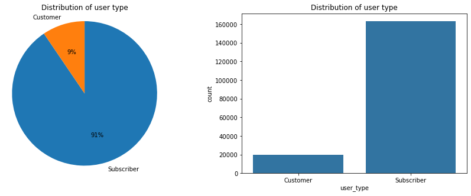

```python
# A sublot of pie chart and bar chart
def pie_bar_plot():
   plt.figure(figsize=[15,5]);

   # Pie chart on the left
   plt.subplot(1,2,1);
   sorted_user = fb_clean.user_type.value_counts();
   plt.pie(sorted_user, labels=sorted_user.index, startangle=90,autopct='%1.0f%%', counterclock=False);
   plt.axis("square");
   plt.title("Distribution of user type");

   # Barplot on the right
   plt.subplot(1,2,2);
   base_color = sb.color_palette()[0]
   sb.countplot(data=fordbike, x="user_type", color=base_color);
   plt.title("Distribution of user type");

pie_bar_plot()
```

From the pie chart and bar chart shown above, it is seen that there are more subscribers compared to customers in fordbike data.

91% of riders are subscribers while 9% are customers.

# What gender is common among the rider?

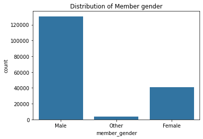

```python
# Distribution of ride frequency by gender
ax = sb.countplot(data=fordbike, x="member_gender", color=sb.color_palette()[0])
total=len(fordbike)
for a in ax.patches:
    percentage = "{:2f}%".format(100 * a.get_height()/total)
    x = a.get_height()+ a.get_width()/2
    y = a.get_height()+0.8
    ax.annotate(percentage, (x, y), ha="center")
    plt.title("Distribution of Member gender");
```

From the bar chart above, it is Deduced that the gender male is common compared to the female and other genders.

i.e Most of the riders are Males

# What is the distribution riders with respect to their age?

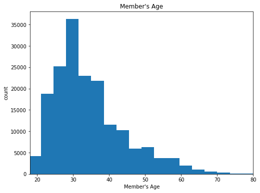

```python
# Histogram showing the distribution of data
plt.figure(figsize=[8,6])
bins=np.arange(0, fb_clean["member_birth_age"].max()+3.5, 3.5)
plt.hist(fb_clean["member_birth_age"].dropna(), bins=bins);
plt.xlim(18, 80)
plt.xlabel("Member's Age")
plt.ylabel("count")
plt.title("Member's Age");
```

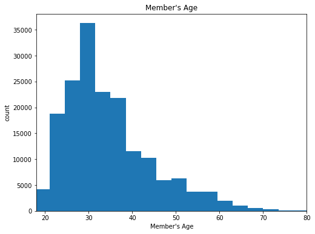

```python
# Histogram showing the distribution of data
plt.figure(figsize=[8,6])
bins=np.arange(0, fb_clean["member_birth_age"].max()+3.5, 3.5)
plt.hist(fb_clean["member_birth_age"].dropna(), bins=bins);
plt.xlim(18, 80)
plt.xlabel("Member's Age")
plt.ylabel("count")
plt.title("Member's Age");
```

> The histogram is right skewed. From the histogram abive it is shown that riders with the most frequency are within their early 20's to their late 30's.

# What is the distribution of duration in sec?

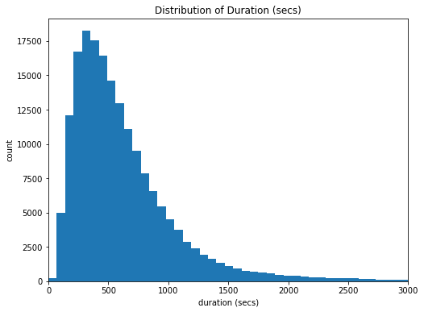

```python
# Histogram showing the distribution of data
def histplot():
   bins = np.arange(0, fordbike["duration_sec"].max()+70, 70)
   plt.figure(figsize=[8, 6])
   plt.hist(data=fordbike, x="duration_sec", bins=bins);
   plt.xlabel("duration (secs)")
   plt.ylabel("count")
   plt.xlim(0, 3000)
   plt.title("Distribution of Duration (secs)");
histplot()
```

The histogram is right skewed and the most frequent duration is between 400 secs

# What is the relationship between day of the week and number of rides?

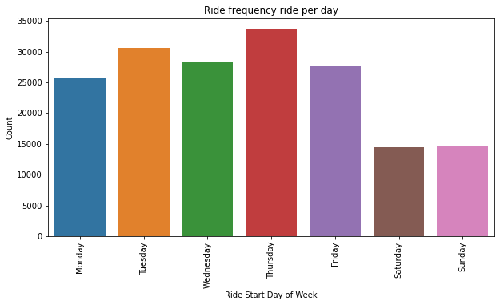

```python
# Bar chart showing the ride frequency by day
days_of_week = ['Monday', 'Tuesday', 'Wednesday', 'Thursday', 'Friday', 'Saturday', 'Sunday']
days_of_week_cat = pd.api.types.CategoricalDtype(ordered=True, categories=days_of_week)
fordbike['start_day'] = fb_clean['start_day'].astype(days_of_week_cat)
plt.figure(figsize=[10, 5])
sb.countplot(data=fb_clean, order=days_of_week, x='start_day');
plt.xlabel('Ride Start Day of Week');
plt.ylabel('Count');
plt.xticks(rotation=90);
plt.title("Ride frequency ride per day");
```

From the bar chart above, most rides were taken on thursday followed by tuesday while saturday and sunday has the lowest number of rides.

# What time was most bike rides started?

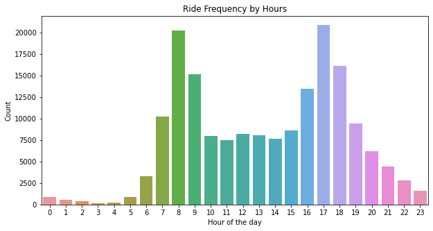

```python
# Bar chart showing the ride frequency by day
plt.figure(figsize=[10, 5])
sb.countplot(data=fb_clean, x='start_hour');
plt.xlabel('Hour of the day');
plt.ylabel('Count');
plt.title("Ride Frequency by Hours");
```

Most rides were taken in the morning within the hour of 8 and 9 and in the evening within the hour and 17 and 18.

# What is the quantity of bike share for all trip?

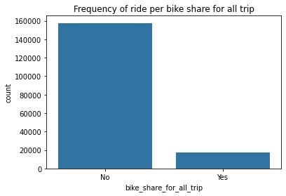

```python
# Distribution of ride frequency by gender
ax = sb.countplot(data=fb_clean, x="bike_share_for_all_trip", color=sb.color_palette()[0])
total=len(fb_clean)
for a in ax.patches:
    percentage = "{:2f}%".format(100 * a.get_height()/total)
    x = a.get_height()+ a.get_width()/2
    y = a.get_height()+0.8
    ax.annotate(percentage, (x, y), ha="center")
    plt.title("Frequency of ride per bike share for all trip");
```

From the bar chart it can be seen that for bike share for all trip, there were more no compared to yes.

# What the top 10 start station with the most trips?

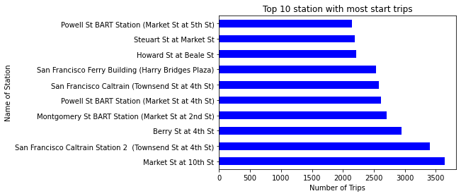

```python
fb_clean.groupby('start_station_name').agg('count')['bike_share_for_all_trip'].sort_values(ascending=False).head(10).plot(kind= 'barh', color= 'blue')
plt.xlabel('Number of Trips')
plt.ylabel('Name of Station')
plt.title('Top 10 station with most start trips');
```

It is observed that the Market St at 10th St station has the highest count for where trips started.

# What the top 10 end station with the most trips?

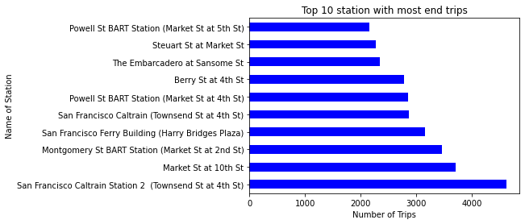

```python
fb_clean.groupby('end_station_name').agg('count')['bike_share_for_all_trip'].sort_values(ascending=False).head(10).plot(kind= 'barh', color= 'blue')
plt.xlabel('Number of Trips')
plt.ylabel('Name of Station')
plt.title('Top 10 station with most end trips');
```

It is observed that the **San Francisco Caltrain Station 2** has the highest count for the station where trips ended.

### Discuss the distribution(s) of your variable(s) of interest. Were there any unusual points? Did you need to perform any transformations?

> In my Univariate visualizations i plotted a bar and pie chart of the user type and i notice that most of the bike users are Subscribers.

### Of the features you investigated, were there any unusual distributions? Did you perform any operations on the data to tidy, adjust, or change the form of the data? If so, why did you do this?

> The data was untidy. So I did some tidiness. I also changed some data types to the appropriate data type. I also added additional columns such as hour, day and month.

## Bivariate Exploration

> In this section, investigate relationships between pairs of variables in your data. Make sure the variables that you cover here have been introduced in some fashion in the previous section (univariate exploration).

# What is the relationship between user type and duration?

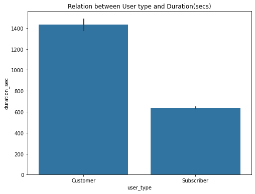

```python
# Relationship between user type and duration
plt.figure(figsize=[8,6])
base_color = sb.color_palette()[0]
sb.barplot(data=fordbike, x="user_type", y="duration_sec", color=base_color)
plt.title("Relation between User type and Duration(secs)");
```

> From the chart, more customers spent more time riding compared to subscribers

# What is the relatioship between user type and gender?

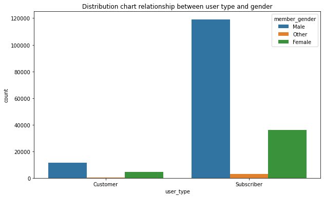

```python
# Relationship between user type and gender
plt.figure(figsize=[10,6])
sb.countplot(data=fordbike, x="user_type", hue="member_gender");
plt.title("Distribution chart relationship between user type and gender");
```

From the Bivariate visualization, males are higher in all user type, there are more males in customer type as well as subscribers type

# What is the relationship between members age and duration time?

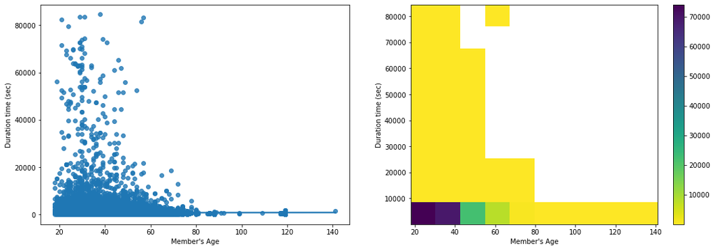

```python
# Plots showing relationship between member's age and duration time
# Size of plots
plt.figure(figsize=[18, 6])

#Plot on left
plt.subplot(1,2,1)
sb.regplot(data=fb_clean, x="member_birth_age", y="duration_sec");
plt.xlabel("Member's Age")
plt.ylabel("Duration time (sec)");

#Plot on the right
plt.subplot(1,2,2)
plt.hist2d(data=fb_clean, x="member_birth_age", y="duration_sec", cmin=0.5, cmap="viridis_r");
plt.colorbar()
plt.xlabel("Member's Age")
plt.ylabel("Duration time (sec)");
```

# What day of the week was duration time high?

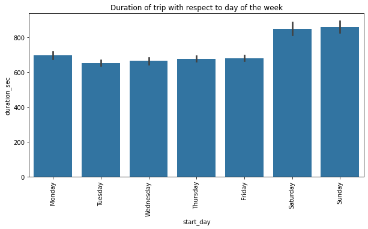

```python
# Duration of trip with respect to day of the week plots
days_of_week = ['Monday', 'Tuesday', 'Wednesday', 'Thursday', 'Friday', 'Saturday', 'Sunday']
plt.figure(figsize=[10, 5])
sb.barplot(data=fb_clean, order= days_of_week, x="start_day", y="duration_sec", color=base_color);
plt.xticks(rotation=90);
plt.title("Duration of trip with respect to day of the week");
```

Unlike the previous univariate visualisation were saturday and sunday had the lowest number of riders. For this visualisation saturday and sunday had the highest ride duration by riders that decided to ride on these two days.

## Multivariate Exploration

> Create plots of three or more variables to investigate your data even further. Make sure that your investigations are justified, and follow from your work in the previous sections.

# What gender travel the longest duration with respect to user type?

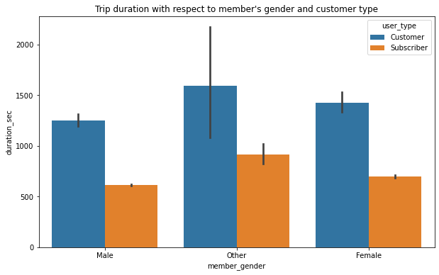

```python
# clustered bar chart of member age, duration sec and user type
plt.figure(figsize=[10,6])
ax = sb.barplot(data=fordbike, x="member_gender", y="duration_sec", hue="user_type")
plt.title("Trip duration with respect to member's gender and customer type");
```

> From this visualisation, the other gender(customers and subscribers) travelled the longest duration, Followed by females then males.

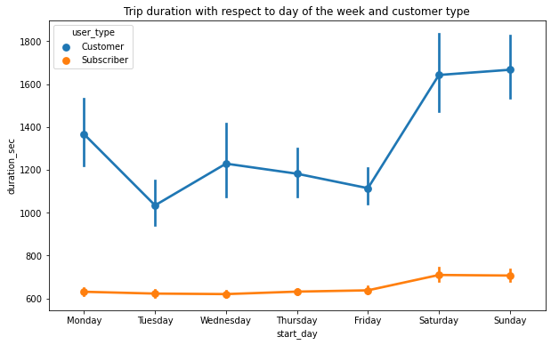

```python
# Point plot of start day, duration sec and user type
days_of_week = ['Monday', 'Tuesday', 'Wednesday', 'Thursday', 'Friday', 'Saturday', 'Sunday']
plt.figure(figsize=[10,6])
ax = sb.pointplot(data=fb_clean, order= days_of_week, x="start_day", y="duration_sec", hue="user_type")
plt.title("Trip duration with respect to day of the week and customer type");
```

From this multiplots, customers travel longes distance compared to subscribers for all days of the week. While subscribes generally travel lower distance.

## Conclusions

- There are about 183,412 data sets which includes some Nan values.
- Data that are Nan are dropped before analysis
- The youngest rider is 18 years and the oldest rider is 141 years
- There are more subscribers compared to customers
- Most riders are in their 20's and 30's
- Males are the most common riders
- Only subscribers were involved in bike sharing
- Customers had the highest duration
- Males are higher in all user type, there are more males in customer type as well as subscribers type